# Lab 03 - Basics of Network Visualization

CRJ 605 Statistical Analysis of Networks

*This lab goes through some basics of visualizing networks using the `gplot()` function in the `sna` package. We also look at some approaches to building plots.*

### **Network Visualization**

One of the great features of working with network data is the ability to *see* the data through visualization. Visualizing the structure of a network is helpful for discerning patterns that might be of interest.

Douglas Luke’s (2015: 47) *A User’s Guide to Network Analysis* provides several guidelines, or aesthetic principles, for what makes a graphical layout of a network easy to understand and interpret. These are:

- Minimize edge crossings.
- Maximize the symmetry of the layout of nodes.
- Minimize the variability of the edge lengths.
- Maximize the angle between edges when they cross or join nodes.
- Minimize the total space used for the network display.

Let’s look at the example he uses as an illustration by working with the `gplot()` function in the `sna` package.

First, we need to install the `sna` package using `install.packages( "sna" )` and load the library using `library( sna )`. Remember, if you have already installed a package then you do not need to use the `install.packages()` function. But, if you have not installed the package in a while, you should use `update.packages()` to incorporate any changes that have been made to the page.

Next, let’s get the `UserNetR` package from [Douglas Luke’s GitHub page](https://github.com/DougLuke/UserNetR). Since this package is not on the CRAN package repository, we need to install it from Github. We do this in four steps:

- First, install the devtools package using `install.packages( "devtools" )`
- And then load the library for the package with `library( devtools )`
- Now, install the `UserNetR` package `install_github( "DougLuke/UserNetR" )`
- Finally, load the library `library( UserNetR )`

Now, let’s take a look at the `Moreno` network (see `help( Moreno, package = UserNetR )`. These data are contained in a sociogram constructed by [Jacob Moreno](https://en.wikipedia.org/wiki/Jacob_L._Moreno), and published in the New York Times in 1933 (see Moreno, J. L. 1934. *Who shall survive? A new approach to the problem of human interrelations*. Nervous and mental disease monograph series, no. 58. Washington, DC: Nervous and Mental Disease Publishing Co. for a more extensive discussion).

```r
# Note that we ask the summary() function to not print out the adjacency matrix.
summary( Moreno, print.adj = FALSE )
```

```
## Network attributes:
##   vertices = 33
##   directed = FALSE
##   hyper = FALSE
##   loops = FALSE
##   multiple = FALSE
##   bipartite = FALSE
##  total edges = 46
##    missing edges = 0
##    non-missing edges = 46
##  density = 0.08712121
##
## Vertex attributes:
##
##  gender:
##    numeric valued attribute
##    attribute summary:
##    Min. 1st Qu.  Median    Mean 3rd Qu.    Max.
##   1.000   1.000   2.000   1.515   2.000   2.000
##   vertex.names:
##    character valued attribute
##    33 valid vertex names
##
## No edge attributes
```

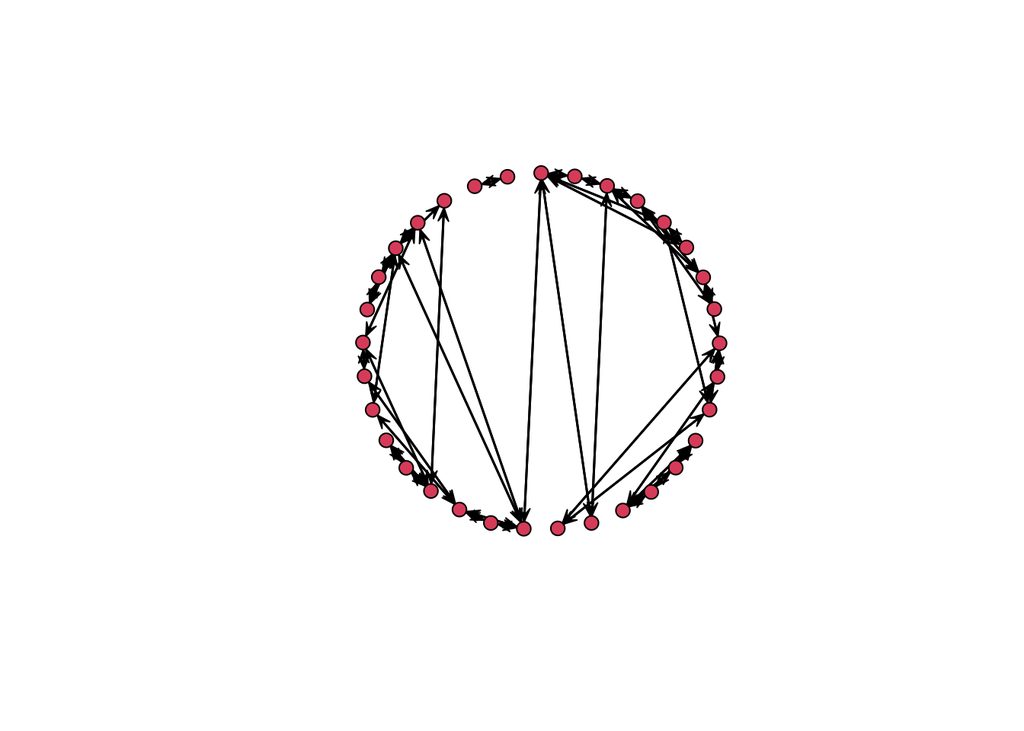

```r
# Now, let's compare two different plot layouts.

# Here is a circle.
gplot( Moreno, mode = "circle" )
```

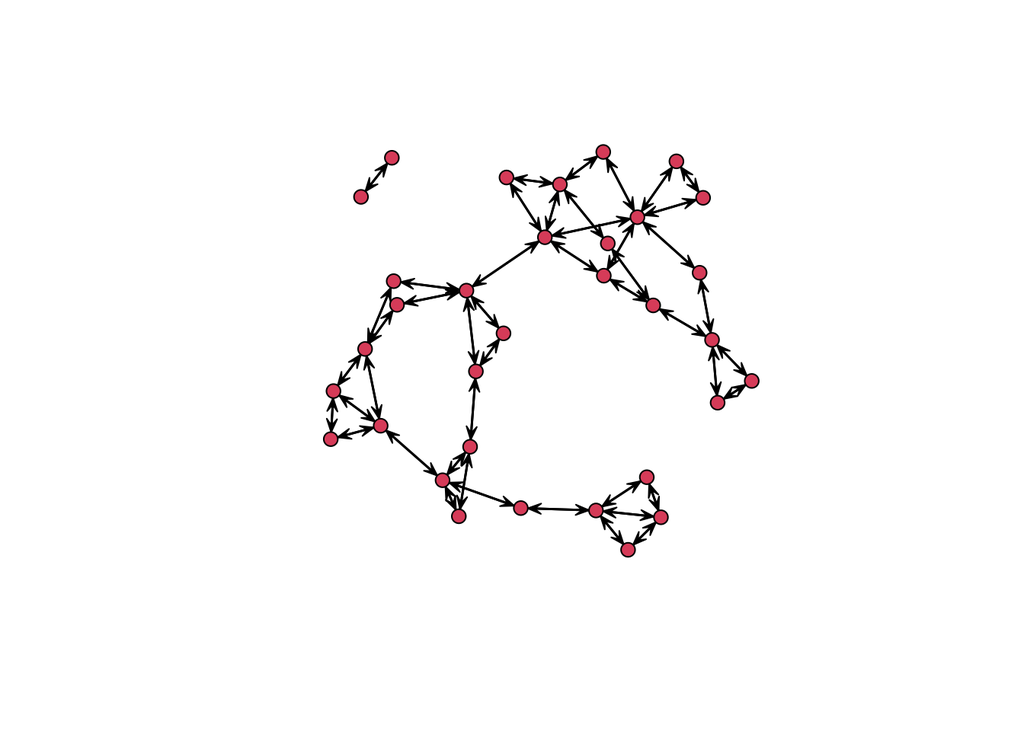

```r
# Here is a separate layout.
gplot( Moreno, mode = "fruchtermanreingold" )
```

##### *How do these plots differ in their ability to highlight the aesthetics mentioned above for relations among individuals?*

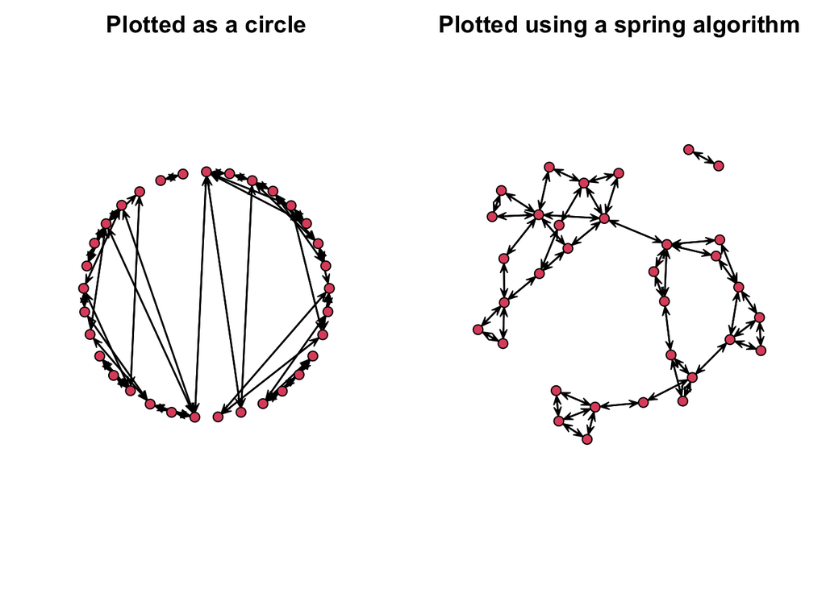

```r
# Let's plot them together for comparison.

# First, we define the plot layout window.
op <- par(
  mar = rep( 2, 4 ), # set the margins
  mfrow = c( 1, 2 )  # se the dimensions
  )

# plot the circle layout (add the main() argument for a title)
gplot( Moreno, mode = "circle", main = "Plotted as a circle" )

# plot the Fruchterman Reingold layout
gplot( Moreno, mode = "fruchtermanreingold", main = "Plotted using a spring algorithm" )
```

If we add information about gender, we can see a bit more that is revealed by the spring algorithm.

To do so, we use the `vertex.col=` argument with the vertex attribute *gender*. To do so, we need to access the vertex attribute. We can do this with:

- the `get.vertex.attribute()` function in the `sna` package. Use `library( sna )` and specify the attribute we want, like `get.vertex.attribute( Moreno, "gender" )`. *What does this command return?*
- or use the shorthand for this with `network object %v% atttribute`, like `Moreno %v% "gender"`.

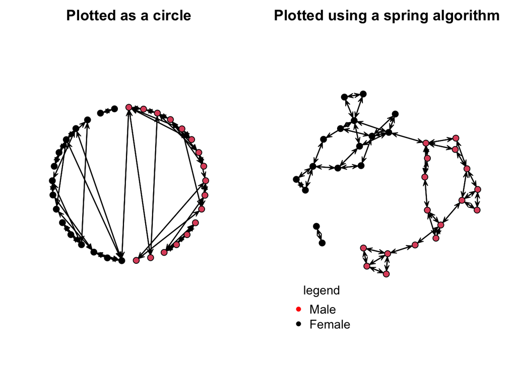

```r
op <- par( mar = rep( 2, 4 ), mfrow = c( 1, 2 ) )

gplot( Moreno,
      mode = "circle",
      main = "Plotted as a circle",
      vertex.col = get.vertex.attribute( Moreno, "gender" ) # use the vertex attribute.
      )

gplot( Moreno,
       mode = "fruchtermanreingold",
       main = "Plotted using a spring algorithm",
       vertex.col = Moreno %v% "gender" # note the difference here compared to above.
       )

# let's add a legend to the plot
legend(
  "bottomleft",
  legend = c( "Male","Female" ),
  col = c( "red","black" ),
  title = "legend",
  pt.cex = 0.75,
  bty = "n",
  pch = 19
  )
```

##### *What is the primary story that the plot tells? Does a particular layout help us see that better?*

### **Working with the `gplot()` function**

Let’s take a look at some of the visualization capabilities of `gplot()`. Let’s start by looking at the function’s help page: `?gplot`.

To see the various functionality of the function, let’s work with the example of an undirected network from [lab 02](https://jacobtnyoung.github.io/SAND/labs/lab-02-nets-intro.html).

```r
# define the path
url <- "https://raw.githubusercontent.com/jacobtnyoung/SAND/main/data/lab_data/lab-02-undirected-example.csv"

# define the object
mat.u <- as.matrix(
  read.csv(
    url,
    as.is = TRUE,
    header = TRUE,
    row.names = 1
    )
  )

# now, create the network
net.u <- network(
  mat.u,
  directed = FALSE
)

# take a look at the network
summary( net.u )
```

```
## Network attributes:
##   vertices = 5
##   directed = FALSE
##   hyper = FALSE
##   loops = FALSE
##   multiple = FALSE
##   bipartite = FALSE
##  total edges = 5
##    missing edges = 0
##    non-missing edges = 5
##  density = 0.5
##
## Vertex attributes:
##   vertex.names:
##    character valued attribute
##    5 valid vertex names
##
## No edge attributes
##
## Network adjacency matrix:
##      Jen Tom Bob Leaf Jim
## Jen    0   1   0    0   0
## Tom    1   0   1    0   0
## Bob    0   1   0    1   1
## Leaf   0   0   1    0   1
## Jim    0   0   1    1   0
```

```r
#NOTE: we could have wrapped all of this into two statements
net.u <- as.network(
  as.matrix(
    read.csv(
      "https://raw.githubusercontent.com/jacobtnyoung/SAND/main/data/lab_data/lab-02-undirected-example.csv",
      as.is = TRUE,
      header = TRUE,
      row.names = 1
      )
    ),
  directed = FALSE
  )

summary( net.u )
```

```
## Network attributes:
##   vertices = 5
##   directed = FALSE
##   hyper = FALSE
##   loops = FALSE
##   multiple = FALSE
##   bipartite = FALSE
##  total edges = 5
##    missing edges = 0
##    non-missing edges = 5
##  density = 0.5
##
## Vertex attributes:
##   vertex.names:
##    character valued attribute
##    5 valid vertex names
##
## No edge attributes
##
## Network adjacency matrix:
##      Jen Tom Bob Leaf Jim
## Jen    0   1   0    0   0
## Tom    1   0   1    0   0
## Bob    0   1   0    1   1
## Leaf   0   0   1    0   1
## Jim    0   0   1    1   0
```

Now that we have the object built, we can plot it.

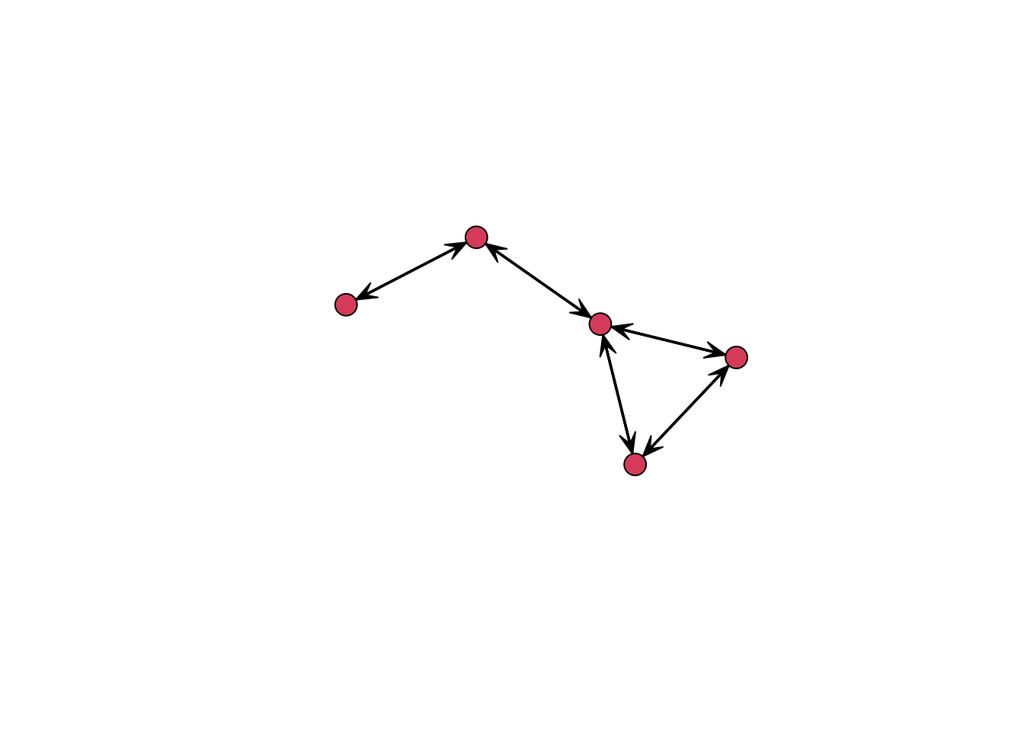

```r
gplot( net.u )
```

*Note*: that this shows arrows. That is because `gplot()` assumes a directed network. We can see this in the help menu, `?gplot`, where is shows that for the type of network, the `gmode=` argument defaults to a directed graph. To fix this we can either:

- manually turn off the display of arrows using the `usearrows=` argument, `gplot( net.u, usearrows = FALSE )`.
- or indicate that the object to be plotted is a undirected graph or graph, `gplot( net.u, gmode = "graph" )`.

The `gplot()` function has a number of arguments that can be used to work try and better display the information contained in the network.

For example, we can add labels to the vertices using the `network.vertex.names()` function.

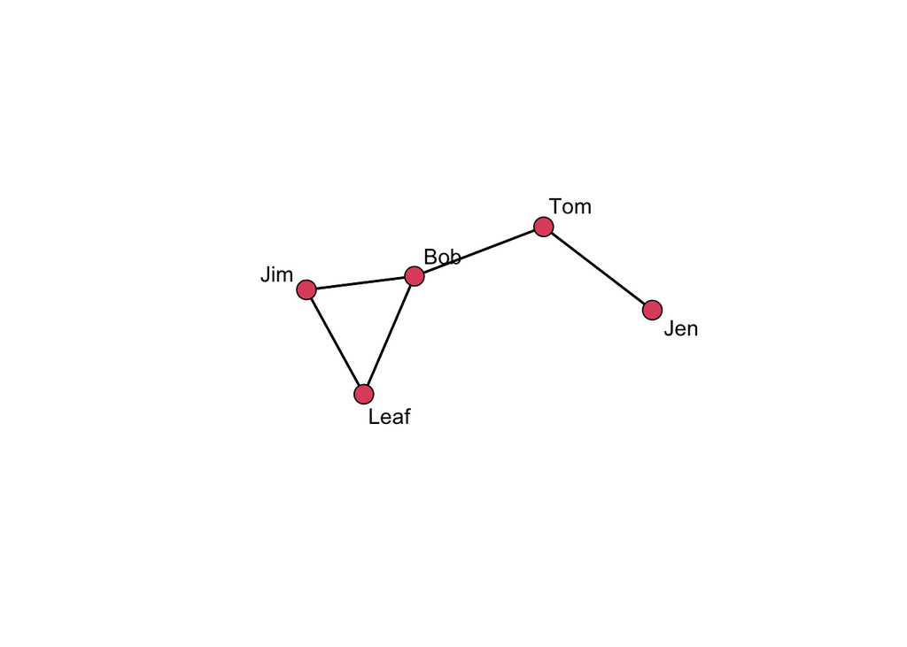

```r
gplot(
  net.u,
  gmode = "graph",
  label = network.vertex.names( net.u )
  )
```

Alternatively, we could add in a string of names for the label:

- `gplot( net.u, gmode = "graph", label = c( "Jen", "Tom", "Bob", "Leaf", "Jim" ) )`

Or we could read them in as an object:

- `names <- c( "Jen", "Tom", "Bob", "Leaf", "Jim" )`
- add to the plot using `gplot( net.u, gmode = "graph", label = names )`

A great feature of R is that we can tune the graphing parameters. Here are several examples:

- Labels:
  - Add boxes around the labels, `boxed.labels = TRUE`
  - Change label size using `label.cex`, such as `label.cex = 1.5`
  - Color the labels using `label.col=`, such as: `label.col = "blue"`
- Colors:
  - different colored names, combine `label.col=` with the `c()` function. Such as: `label.col = c( "red", "blue", "green", "orange", "grey" )`
  - different colored nodes, `vertex.col=` argument. Such as: `vertex.col=c("red","blue","green","orange","grey")`
  - different colored edges, using `edge.col=`, such as: `edge.col=c("red","blue","green","orange","grey")`

There is a LOT of functionality to the `gplot()` function. See the arguements in the help file: `?gplot`. I would encourage you to take some time to look through it and play around with the various features.

### **Adjusting Plot Layout**

When a layout is generated, the results can be saved for later reuse using the `coord=` argument.

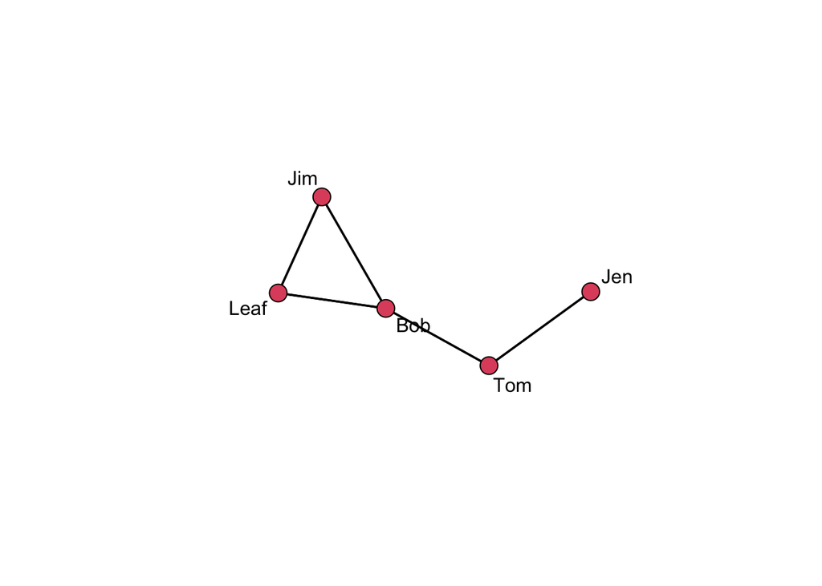

```r
# Set the seed for the random number generator
# so we can always get the same plot layout.
set.seed( 605 )

# Define an object that will be the coordinates we want to use.
coords <- gplot(
  net.u,
  gmode = "graph",
  label = network.vertex.names( net.u )
  )
```

```r
# Show the vertex coordinates.
coords
```

```
##               x         y
## [1,]  -7.774055 -3.174038
## [2,]  -9.087120 -4.129350
## [3,] -10.417427 -3.389680
## [4,] -11.806461 -3.191055
## [5,] -11.243429 -1.949167
```

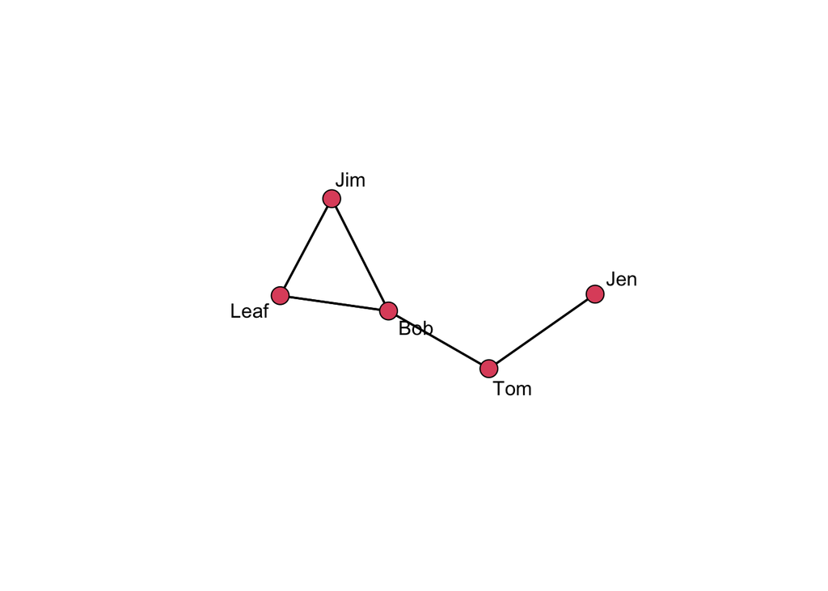

```r
# Saved (or a priori) layouts can be used via the coord= argument:
gplot(
  net.u,
  gmode = "graph",
  label = network.vertex.names( net.u ),
  coord = coords
  )
```

*Why do this?* The placement of the nodes shift when we call the `gplot()` function just due to the operation of the algorithm. This is useful if we want to show different aspects of the plot. Note that we can have different layouts of the nodes. If we like a particular one, we can save the coordinates.

*But*, suppose the default settings are insufficient and we want to make a few small changes. The `interactive=` argument allows for tweaking.

```r
# First, set up the coordinates you want.
coords <- gplot(
  net.u,
  gmode = "graph",
  label = network.vertex.names( net.u ),
  coord = coords,
  interactive=TRUE
  )

# Then, use these in the plot.
gplot(
  net.u,
  coord = coords,
  gmode = "graph",
  label=network.vertex.names( net.u )
  )
```

There is also the option to do three-dimensional visualization with `gplot3d()`, which requires the rgl package. Let’s take a look at this by first installing the `rgl` package using `install.packages( "rgl" )` and then loading the library with `library( rgl )`. Then, we can look at the `gplot3d()` function using help: `?gplot3d`. *Note* that the `rgl` packages requires the program XQuartz if you are using a Mac. It can be downloaded from: https://www.xquartz.org/.

```r
gplot3d(
  net.u,
  label = network.vertex.names( net.u )
  )
```

### **Class data example**

Now let’s take a look at the class data to continue working with the `gplot()` function. First, load the .RData file from my website.

```r
# First, clear the workspace.
rm(list = ls())

# Now, load the file.
#load(url("https://www.jacobtnyoung.com/uploads/2/3/4/5/23459640/crj_605_networks_spring_2019_class_survey_data_w1.rdata"))

#Take a look at the object.
ls()
```

There is the non-network data:

- `class.data.w1`

And there are three networks:

- `spend.time.net` the Spent Time With network
- `talk.course.net` the Talked about the Course network
- `trust.net` the Trust with Damaging information network

For each network, the survey data have been attached to the objects as vertex attributes. Also, each network object the two other networks have been attached as edge attributes. We can see this by using the `summary()` function.

Let’s work with the `spend.time.net` object. This is the network for whether ego spends time with alter outside of class.

```r
summary(spend.time.net, print.adj=FALSE)
```

[output not shown]

#### *What does the summary of this network tell us?*

We can look at the various vertex data by using the shorthand `network %v% "attribute"`. For example:

- `spend.time.net %v% "Sleept1"` shows the response categories to the question, *last week, how many hours of sleep did you get per night (on average)?*
- `spend.time.net %e% "talk.course.net"` shows the edges for the `talk.course.net` mapped to the edges for the `spend.time.net`.

Then, use that info in a plot. For example:

```r
gplot(spend.time.net,vertex.cex=spend.time.net %v% "Sleept1") #size the nodes by the amount of sleep.
#Yike!
```

[output not shown]

The problem is that we need to rescale the vertex attribute so that the nodes are not too big. Let’s build a function to do that and then execute the `gplot()` function:

```r
rescale <- function(nchar,low,high){
  min_d <- min(nchar)
  max_d <- max(nchar)
  rscl  <- ((high-low)*(nchar-min_d)) / (max_d-min_d)+low
  rscl
}

#Now, use the function we created to rescale the vertex attribute.
gplot(spend.time.net,vertex.cex=rescale(spend.time.net %v% "Sleept1", 0.5, 1.5),arrowhead.cex=0.5)
# that looks better!
```

[output not shown]

```r
set.seed(605)
coords <- gplot(spend.time.net)
```

```r
#Now, let's add additional information to the plot:
gplot(spend.time.net,arrowhead.cex=0.5, coord=coords, label.cex=0.75,
        main="Spend Time Network", # add a title.
        vertex.col= spend.time.net %v% "KnowNett1", # color nodes based on prior knowledge of networks.
        vertex.cex=rescale(spend.time.net %v% "Sleept1", 0.5, 1.5), # size the nodes by time sleep.
        vertex.sides=(spend.time.net %v% "GenTrustt1")+2, #trust is the sides (note the addition of 2).
        label=spend.time.net %v% "vertex.names", #label the nodes.
        sub="Nodes colored by knowledge of networks\n Nodes sized by time sleeping\n Nodes shaped by trust (square is cant be trusted)"
      )
```

[output not shown]

#### *Questions?*

##### *Please* report any needed corrections to the [Issues](https://github.com/jacobtnyoung/SAND/issues/new) page. Thanks!

###### *Last updated 09 December, 2022*